# Homework 3

Kevin Sanchez

05/03/2020

## Challenge 1

```r
library(curl)
file <- curl("https://raw.githubusercontent.com/difiore/ADA-datasets/master/KamilarAndCooperData.csv")
KC_Raw <- read.csv(file, header = TRUE, sep = ",", stringsAsFactors = FALSE)
head(KC_Raw)
```

```
##               Scientific_Name          Family          Genus      Species
## 1 Allenopithecus_nigroviridis Cercopithecidae Allenopithecus nigroviridis
## 2         Allocebus_trichotis Cercopithecidae      Allocebus    trichotis
## 3           Alouatta_belzebul        Atelidae       Alouatta     belzebul
## 4             Alouatta_caraya        Atelidae       Alouatta       caraya
## 5            Alouatta_guariba        Atelidae       Alouatta      guariba
## 6           Alouatta_palliata        Atelidae       Alouatta     palliata
##   Brain_Size_Species_Mean Brain_Size_Female_Mean   Brain_size_Ref
## 1                   58.02                  53.70 Isler et al 2008
## 2                      NA                     NA
## 3                   52.84                  51.19 Isler et al 2008
## 4                   52.63                  47.80 Isler et al 2008
## 5                   51.70                  49.08 Isler et al 2008
## 6                   49.88                  48.04 Isler et al 2008
##   Body_mass_male_mean Body_mass_female_mean Mass_Dimorphism
```

[output cut: 62 more lines]

```r
library(ggplot2)
fit = lm(KC_Raw$MaxLongevity_m ~ KC_Raw$Brain_Size_Species_Mean)
summary(fit)
```

```
##
## Call:
## lm(formula = KC_Raw$MaxLongevity_m ~ KC_Raw$Brain_Size_Species_Mean)
##
## Residuals:
##     Min      1Q  Median      3Q     Max
## -198.27  -61.92  -17.78   56.16  331.36
##
## Coefficients:
##                                Estimate Std. Error t value Pr(>|t|)
## (Intercept)                    248.9523    11.1111   22.41   <2e-16 ***
## KC_Raw$Brain_Size_Species_Mean   1.2180     0.1101   11.06   <2e-16 ***
## ---
## Signif. codes:  0 '***' 0.001 '**' 0.01 '*' 0.05 '.' 0.1 ' ' 1
##
## Residual standard error: 90.91 on 126 degrees of freedom
##   (85 observations deleted due to missingness)
## Multiple R-squared:  0.4928, Adjusted R-squared:  0.4887
## F-statistic: 122.4 on 1 and 126 DF,  p-value: < 2.2e-16
```

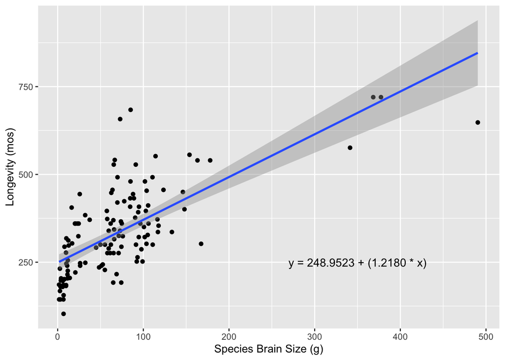

```r
LvBS <- ggplot(data = KC_Raw, aes(x = Brain_Size_Species_Mean, y = MaxLongevity_m)) +
  geom_point(na.rm = TRUE) +
  xlab("Species Brain Size (g)") +
  ylab("Longevity (mos)") +
  geom_smooth(method = "lm", na.rm = TRUE) +
  annotate("text", label = "y = 248.9523 + (1.2180 * x)", size = 4, x = 350, y = 250)
LvBS
```

```r
library(dplyr)
KC_Raw <- KC_Raw %>%  mutate(
  log_MaxLongevity_m = log(MaxLongevity_m),
  log_Brain_Size_Species_Mean = log(Brain_Size_Species_Mean)
)

fit_log = lm(KC_Raw$log_MaxLongevity_m ~ KC_Raw$log_Brain_Size_Species_Mean)
summary(fit_log)
```

```
##
## Call:
## lm(formula = KC_Raw$log_MaxLongevity_m ~ KC_Raw$log_Brain_Size_Species_Mean)
##
## Residuals:
##     Min      1Q  Median      3Q     Max
## -0.6955 -0.1750 -0.0097  0.1788  0.6084
##
## Coefficients:
##                                    Estimate Std. Error t value Pr(>|t|)
## (Intercept)                         4.87895    0.06907   70.63   <2e-16 ***
## KC_Raw$log_Brain_Size_Species_Mean  0.23415    0.01781   13.15   <2e-16 ***
## ---
## Signif. codes:  0 '***' 0.001 '**' 0.01 '*' 0.05 '.' 0.1 ' ' 1
##
## Residual standard error: 0.2485 on 126 degrees of freedom
##   (85 observations deleted due to missingness)
## Multiple R-squared:  0.5784, Adjusted R-squared:  0.5751
## F-statistic: 172.9 on 1 and 126 DF,  p-value: < 2.2e-16
```

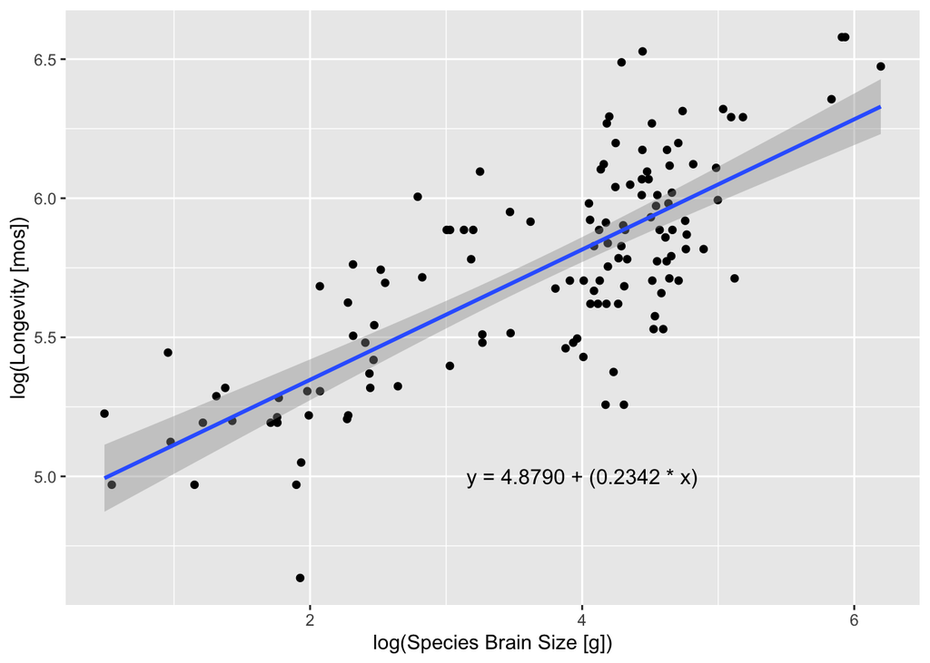

```r
log_LvBS <- ggplot(data = KC_Raw, aes(x = log_Brain_Size_Species_Mean, y = log_MaxLongevity_m)) +
  geom_point(na.rm = TRUE) +
  xlab("log(Species Brain Size [g])") +
  ylab("log(Longevity [mos])") +
  geom_smooth(method = "lm", na.rm = TRUE) +
  annotate("text", label = "y = 4.8790 + (0.2342 * x)", size = 4, x = 4, y = 5)
log_LvBS
```

The null hypothesis states that we would expect the point estimate of the slope to be equal to zero, whereas the alternative hypothesis is that the slope is non-zero. From the original data, the slope is equal to 1.2180 mos/g. Similarly, the slope in the log-transformed data is 0.2342 log(mos)/log(g). In both cases, we reject the null hypothesis in favor of the alternative hypothesis. Additionally, the greater the magnitude of the t-statistic, the more likely it is to reject the null hypothesis. Both the original and transformed data have a Pr(>|t|) of under 0.001.

```r
library(broom)
(CI_original <- tidy(fit, conf.int = TRUE, conf.level = 0.90))
```

```
## # A tibble: 2 x 7
##   term                  estimate std.error statistic  p.value conf.low conf.high
##   <chr>                    <dbl>     <dbl>     <dbl>    <dbl>    <dbl>     <dbl>
## 1 (Intercept)             249.      11.1        22.4 8.91e-46   231.      267.
## 2 KC_Raw$Brain_Size_Sp…     1.22     0.110      11.1 2.69e-20     1.04      1.40
```

```r
(CI_transformed <- tidy(fit_log, conf.int = TRUE, conf.level = 0.90))
```

```
## # A tibble: 2 x 7
##   term                 estimate std.error statistic   p.value conf.low conf.high
##   <chr>                   <dbl>     <dbl>     <dbl>     <dbl>    <dbl>     <dbl>
## 1 (Intercept)             4.88     0.0691      70.6 3.32e-103    4.76      4.99
## 2 KC_Raw$log_Brain_Si…    0.234    0.0178      13.1 2.17e- 25    0.205     0.264
```

The 90% confidence interval for the slope in the original data is between 1.04 and 1.40 mos/g. In the log-transformed data, this 90% confidence interval for the slope is between 0.205 and 0.264 log(mos)/log(g).

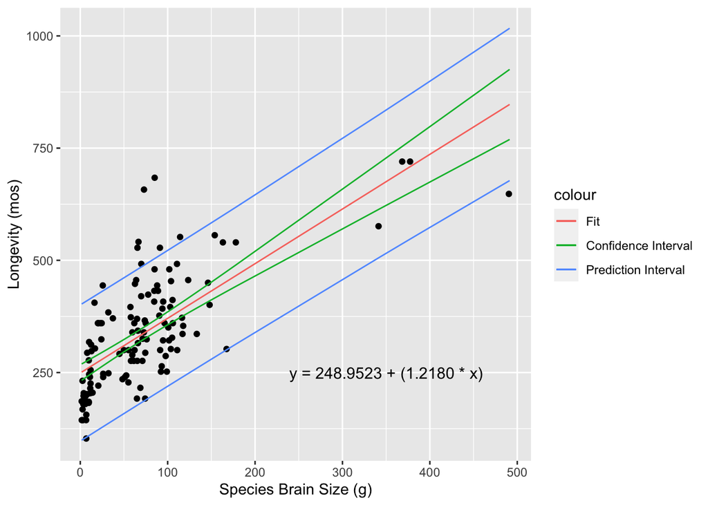

```r
alpha = 0.10

CI_fit <- predict(fit,
  newdata = data.frame(Brain_Size_Species_Mean = KC_Raw$Brain_Size_Species_Mean),
  interval = "confidence", level = 1 - alpha)
CI_fit <- data.frame(CI_fit)
CI_fit <- cbind(KC_Raw$Brain_Size_Species_Mean, CI_fit)
names(CI_fit) <- c("Brain_Size", "c.fit", "c.lwr", "c.upr")

PI_fit <- predict(fit,
  newdata = data.frame(Brain_Size_Species_Mean = KC_Raw$Brain_Size_Species_Mean),
  interval = "prediction", level = 1 - alpha)
PI_fit <- data.frame(PI_fit)
PI_fit <- cbind(KC_Raw$Brain_Size_Species_Mean, PI_fit)
names(PI_fit) <- c("Brain_Size", "p.fit", "p.lwr", "p.upr")

LvBS_CP <- ggplot(KC_Raw, aes(y = MaxLongevity_m, x = Brain_Size_Species_Mean)) +
  geom_point(na.rm = TRUE) +
  xlab("Species Brain Size (g)") +
  ylab("Longevity (mos)") +
  annotate("text", label = "y = 248.9523 + (1.2180 * x)", size = 4, x = 350, y = 250) +
  geom_line(data = CI_fit, aes(x = Brain_Size, y = c.fit, color = "black"), na.rm = TRUE) +
  geom_line(data = CI_fit, aes(x = Brain_Size, y = c.lwr, color = "blue"), na.rm = TRUE) +
  geom_line(data = CI_fit, aes(x = Brain_Size, y = c.upr, color = "blue"), na.rm = TRUE) +
  geom_line(data = PI_fit, aes(x = Brain_Size, y = p.lwr, color = "green"), na.rm = TRUE) +
  geom_line(data = PI_fit, aes(x = Brain_Size, y = p.upr, color = "green"), na.rm = TRUE) +
  scale_color_hue(labels = c("Fit", "Confidence Interval", "Prediction Interval"))
LvBS_CP
```

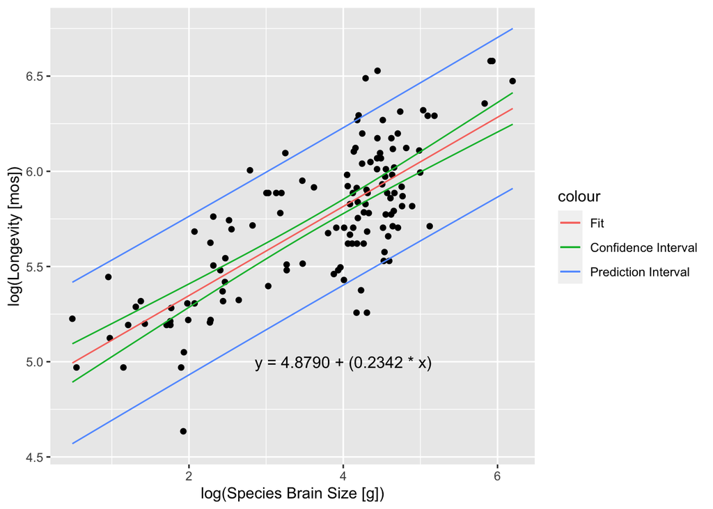

```r
CI_fit_log <- predict(fit_log,
  newdata = data.frame(log_Brain_Size_Species_Mean = KC_Raw$log_Brain_Size_Species_Mean),
  interval = "confidence", level = 1 - alpha)
CI_fit_log <- data.frame(CI_fit_log)
CI_fit_log <- cbind(KC_Raw$log_Brain_Size_Species_Mean, CI_fit_log)
names(CI_fit_log) <- c("log_Brain_Size", "c.fit", "c.lwr", "c.upr")

PI_fit_log <- predict(fit_log,
  newdata = data.frame(log_Brain_Size_Species_Mean = KC_Raw$log_Brain_Size_Species_Mean),
  interval = "prediction", level = 1 - alpha)
PI_fit_log <- data.frame(PI_fit_log)
PI_fit_log <- cbind(KC_Raw$log_Brain_Size_Species_Mean, PI_fit_log)
names(PI_fit_log) <- c("log_Brain_Size", "p.fit", "p.lwr", "p.upr")

LvBS_CP_log <- ggplot(KC_Raw, aes(y = log_MaxLongevity_m, x = log_Brain_Size_Species_Mean)) +
  geom_point(na.rm = TRUE) +
  xlab("log(Species Brain Size [g])") +
  ylab("log(Longevity [mos])") +
  annotate("text", label = "y = 4.8790 + (0.2342 * x)", size = 4, x = 4, y = 5) +
  geom_line(data = CI_fit_log, aes(x = log_Brain_Size, y = c.fit, color = "black"), na.rm = TRUE) +
  geom_line(data = CI_fit_log, aes(x = log_Brain_Size, y = c.lwr, color = "blue"), na.rm = TRUE) +
  geom_line(data = CI_fit_log, aes(x = log_Brain_Size, y = c.upr, color = "blue"), na.rm = TRUE) +
  geom_line(data = PI_fit_log, aes(x = log_Brain_Size, y = p.lwr, color = "green"), na.rm = TRUE) +
  geom_line(data = PI_fit_log, aes(x = log_Brain_Size, y = p.upr, color = "green"), na.rm = TRUE) +
  scale_color_hue(labels = c("Fit", "Confidence Interval", "Prediction Interval"))
LvBS_CP_log
```

```r
(L_750 <- 248.9523 + (1.2180 * 750))
```

```
## [1] 1162.452
```

```r
L_750_P <- predict(fit,
  newdata = data.frame(Brain_Size_Species_Mean = 750),
  interval = "prediction",
  level = 1 - alpha,
  na.rm = TRUE)
L_750_P
```

```
##          fit       lwr       upr
## 1   319.6201 168.37503  470.8651
## 2         NA        NA        NA
## 3   313.3109 162.04957  464.5722
## 4   313.0551 161.79301  464.3172
## 5   311.9224 160.65669  463.1880
## 6   309.7056 158.43237  460.9789
## 7   311.2281 159.96014  462.4961
## 8   316.2097 164.95660  467.4628
## 9   274.1281 122.63379  425.6225
## 10        NA        NA        NA
## 11  268.8055 117.26202  420.3490
## 12        NA        NA        NA
## 13        NA        NA        NA
## 14  269.4754 117.93833  421.0125
```

[output cut: 199 more lines]

```r
(L_750_log <- 4.8790 + (0.2342 * 2.87506))
```

```
## [1] 5.552339
```

```r
L_750_log_P <- predict(fit_log,
  newdata = data.frame(log_Brain_Size_Species_Mean = 2.87506),
  interval = "prediction",
  level = 1 - alpha,
  na.rm = TRUE)
L_750_log_P
```

```
##          fit      lwr      upr
## 1   5.829783 5.416322 6.243243
## 2         NA       NA       NA
## 3   5.807885 5.394491 6.221279
## 4   5.806953 5.393561 6.220344
## 5   5.802778 5.389397 6.216159
## 6   5.794387 5.381024 6.207749
## 7   5.800182 5.386807 6.213557
## 8   5.818201 5.404778 6.231624
## 9   5.588116 5.174367 6.001864
## 10        NA       NA       NA
## 11  5.532501 5.118369 5.946633
## 12        NA       NA       NA
## 13        NA       NA       NA
## 14  5.540271 5.126200 5.954343
```

[output cut: 199 more lines]

The point estimate for longevity of a species with a brain mass of 750 g was 1,162.5 mos (or 96.9 yrs). This is outside the range based on the model and there were no species with either a brain mass or longevity of this magnitude. Therefore, I would not trust the model to predict and extrapolate observations that are far off from the points in the data set.

The log-log transformed data appears to be better. It has both a higher t-statistic and R<sup>2</sup> value compared to the original data. This indicates a better linear fit and likelihood of rejecting the null hypothesis, respectively.

## Challenge 2

```r
KC_Raw <- KC_Raw %>%  mutate(
  log_HomeRange_km2 = log(HomeRange_km2),
  log_Body_mass_female_mean = log(Body_mass_female_mean))

(RvFBM <- lm(KC_Raw$log_HomeRange_km2 ~ KC_Raw$log_Body_mass_female_mean))
```

```
##
## Call:
## lm(formula = KC_Raw$log_HomeRange_km2 ~ KC_Raw$log_Body_mass_female_mean)
##
## Coefficients:
##                      (Intercept)  KC_Raw$log_Body_mass_female_mean
##                           -9.441                             1.036
```

The slope is equal to 1.036 log(km<sup>2</sup>)/log(kg) and the intercept is -9.441 log(km<sup>2</sup>).

```r
library(infer)
boot.strap <- KC_Raw %>%
  specify(log_HomeRange_km2 ~ log_Body_mass_female_mean) %>%
  generate(reps = 1000, type = "bootstrap")
```

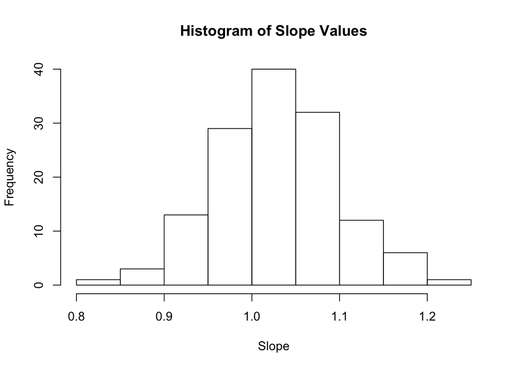

```r
slope <- vector()
intercept <- vector()
for (i in 1:137) {
  Reps <- filter(boot.strap, replicate == i)
  RvFBM_B <- lm(log_HomeRange_km2 ~ log_Body_mass_female_mean, data = Reps)
  slope[[i]] <- RvFBM_B$coefficients[[2]]
  intercept[[i]] <- RvFBM_B$coefficients[[1]]
}

RvFBM_Boot <- tibble(slope = slope, intercept = intercept)

hist(RvFBM_Boot$slope,
  main = "Histogram of Slope Values",
  xlab = "Slope")
```

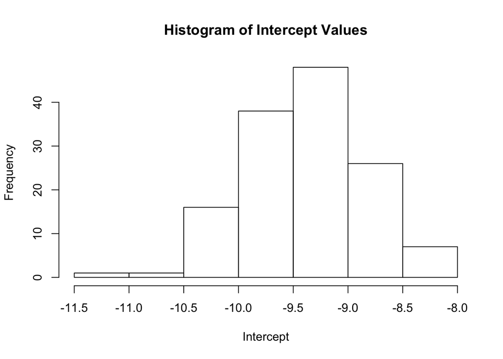

```r
hist(RvFBM_Boot$intercept,
  main = "Histogram of Intercept Values",
  xlab = "Intercept")
```

```r
alpha <- 0.05
CI_level <- 1 - alpha
p_lower <- alpha / 2
p_upper <- 1 - (alpha / 2)
DOF <- nrow(RvFBM_Boot) - 2
crit_value <- qt(p_upper, df = DOF)

boot.slope.summary <- RvFBM_Boot %>%
  summarize(
    estimate = mean(slope),
    std.error = sd(slope),
    lower = estimate - std.error * crit_value,
    upper = estimate + std.error * crit_value,
    boot.lower = quantile(slope, p_lower),
    boot.upper = quantile(slope, p_upper)
    )
boot.slope.summary
```

```
## # A tibble: 1 x 6
##   estimate std.error lower upper boot.lower boot.upper
##      <dbl>     <dbl> <dbl> <dbl>      <dbl>      <dbl>
## 1     1.03    0.0686 0.893  1.16      0.897       1.15
```

```r
boot.intercept.summary <- RvFBM_Boot %>%
  summarize(
    estimate = mean(intercept),
    std.error = sd(intercept),
    lower = estimate - std.error * crit_value,
    upper = estimate + std.error * crit_value,
    boot.lower = quantile(intercept, p_lower),
    boot.upper = quantile(intercept, p_upper)
    )
boot.intercept.summary
```

```
## # A tibble: 1 x 6
##   estimate std.error lower upper boot.lower boot.upper
##      <dbl>     <dbl> <dbl> <dbl>      <dbl>      <dbl>
## 1    -9.40     0.540 -10.5 -8.33      -10.4      -8.37
```

```r
fit_log <- lm(KC_Raw$log_HomeRange_km2 ~ KC_Raw$log_Body_mass_female_mean)
summary(fit_log)
```

```
##
## Call:
## lm(formula = KC_Raw$log_HomeRange_km2 ~ KC_Raw$log_Body_mass_female_mean)
##
## Residuals:
##     Min      1Q  Median      3Q     Max
## -3.3929 -0.9433 -0.0126  1.0944  3.6826
##
## Coefficients:
##                                  Estimate Std. Error t value Pr(>|t|)
## (Intercept)                      -9.44123    0.67293  -14.03   <2e-16 ***
## KC_Raw$log_Body_mass_female_mean  1.03643    0.08488   12.21   <2e-16 ***
## ---
## Signif. codes:  0 '***' 0.001 '**' 0.01 '*' 0.05 '.' 0.1 ' ' 1
##
## Residual standard error: 1.423 on 135 degrees of freedom
##   (76 observations deleted due to missingness)
## Multiple R-squared:  0.5248, Adjusted R-squared:  0.5213
## F-statistic: 149.1 on 1 and 135 DF,  p-value: < 2.2e-16
```

```r
(CI_transformed <- tidy(fit_log, conf.int = TRUE, conf.level = 0.95))
```

```
## # A tibble: 2 x 7
##   term                  estimate std.error statistic  p.value conf.low conf.high
##   <chr>                    <dbl>     <dbl>     <dbl>    <dbl>    <dbl>     <dbl>
## 1 (Intercept)              -9.44    0.673      -14.0 3.82e-28  -10.8       -8.11
## 2 KC_Raw$log_Body_mass…     1.04    0.0849      12.2 1.45e-23    0.869      1.20
```

## Challenge 3

```r
boot_lm <- function(d, model, conf.level = 0.95, reps = 1000) {
  d_mod <- d %>% mutate(
    logHR = log(HomeRange_km2),
    logFBM = log(Body_mass_female_mean),
    logDL = log(DayLength_km),
    MGS = MeanGroupSize
    )

  model <- as.formula(model)

  fit <- lm(model, data = d_mod)

  boot.strap <- d_mod %>%
    generate(reps = reps, type = "bootstrap")

  slope <- vector()
  intercept <- vector()

  for (i in 1:137) {
    Reps <- filter(boot.strap, replicate == i)
    Boot <- lm(model, data = Reps)
    slope[[i]] <- Boot$coefficients[[2]]
    intercept[[i]] <- Boot$coefficients[[1]]
  }

  Bootstrap <- tibble(
    slope = slope,
    intercept = intercept)

  confidence_level <- conf.level
  alpha <- 1 - confidence_level
  p_lower <- alpha / 2
  p_upper <- 1 - (alpha / 2)
  DOF <- nrow(Bootstrap) - 2
  crit_value <- qt(p_upper, df = DOF)

  Bootstrap <- Bootstrap %>%
    summarize(
      model.type = "Bootstrap",
      slope.M = mean(slope, na.rm = TRUE),
      slope.SE = sd(slope, na.rm = TRUE),
      slope.CI_l = quantile(slope, p_lower, na.rm = TRUE),
      slope.CI_u = quantile(slope, p_upper, na.rm = TRUE),
      intercept.M = mean(intercept, na.rm = TRUE),
      intercept.SE = sd(intercept, na.rm = TRUE),
      intercept.CI_l = quantile(intercept, p_lower, na.rm = TRUE),
      intercept.CI_u = quantile(intercept, p_upper, na.rm = TRUE)
      )

  lm_mod <- tibble(
    model.type = "LRM",
    slope.M = fit$coefficients[2],
    slope.SE = tidy(fit)$std.error[2],
    slope.CI_l =  tidy(fit, conf.int = TRUE, conf.level = confidence_level)$conf.low[2],
    slope.CI_u =  tidy(fit, conf.int = TRUE, conf.level = confidence_level)$conf.high[2],
    intercept.M = fit$coefficients[1],
    intercept.SE = tidy(fit)$std.error[1],
    intercept.CI_l = tidy(fit, conf.int = TRUE, conf.level = confidence_level)$conf.low[1],
    intercept.CI_u = tidy(fit, conf.int = TRUE, conf.level = confidence_level)$conf.high[1]
    )

  lmvB <- rbind(lm_mod, Bootstrap)
  lmvB
}

boot_lm(d = KC_Raw, model = "logHR ~ logFBM")
```

```
## # A tibble: 2 x 9
##   model.type slope.M slope.SE slope.CI_l slope.CI_u intercept.M intercept.SE
##   <chr>        <dbl>    <dbl>      <dbl>      <dbl>       <dbl>        <dbl>
## 1 LRM           1.04   0.0849      0.869       1.20       -9.44        0.673
## 2 Bootstrap     1.04   0.0787      0.889       1.18       -9.44        0.619
## # … with 2 more variables: intercept.CI_l <dbl>, intercept.CI_u <dbl>
```

```r
boot_lm(d = KC_Raw, model = "logDL ~ logFBM")
```

```
## # A tibble: 2 x 9
##   model.type slope.M slope.SE slope.CI_l slope.CI_u intercept.M intercept.SE
##   <chr>        <dbl>    <dbl>      <dbl>      <dbl>       <dbl>        <dbl>
## 1 LRM         0.0389   0.0567    -0.0735      0.151      -0.143        0.465
## 2 Bootstrap   0.0386   0.0560    -0.0467      0.163      -0.144        0.434
## # … with 2 more variables: intercept.CI_l <dbl>, intercept.CI_u <dbl>
```

```r
boot_lm(d = KC_Raw, model = "logHR ~ logFBM + MGS")
```

```
## # A tibble: 2 x 9
##   model.type slope.M slope.SE slope.CI_l slope.CI_u intercept.M intercept.SE
##   <chr>        <dbl>    <dbl>      <dbl>      <dbl>       <dbl>        <dbl>
## 1 LRM          0.850   0.0942      0.663      1.04        -8.66        0.698
## 2 Bootstrap    0.844   0.0786      0.664      0.981       -8.61        0.596
## # … with 2 more variables: intercept.CI_l <dbl>, intercept.CI_u <dbl>
```